# HW6

2023-04-05

##Problem 1 ##Part 1

##reading in data

```r
sagebrush <- read.table("http://users.stat.umn.edu/~gary/book/fcdae.data/pr8.7",
                        header=TRUE, colClasses = c("factor", "factor", "numeric"))
```

##reading in first few lines

```r
head(sagebrush)
```

```
##   storage hum    y
## 1       1   1 82.1
## 2       1   1 79.0
## 3       1   1 81.9
## 4       2   1 78.6
## 5       2   1 80.8
## 6       2   1 80.5
```

##counting the number of of observations for each combo of factors

```r
xtabs(~ storage + hum, data = sagebrush)
```

```
##        hum
## storage 1 2 3
##       1 3 3 3
##       2 3 3 3
##       3 3 3 3
##       4 3 3 3
##       5 3 3 3
##       6 3 3 3
##       7 3 3 3
```

##Creating an interaction plot

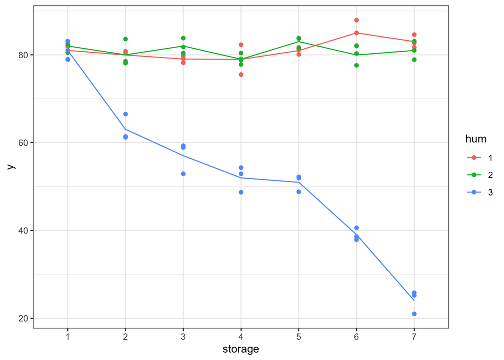

```r
library(ggplot2)
ggplot(sagebrush, aes(x = storage, y = y, color = hum)) + geom_point() +
  stat_summary(fun = mean, geom = "line", aes(group = hum)) + theme_bw()
```

##The humidity does seem to change the effect of longer storage times on seed viability. Looking at humidity 1 and 2 which are 0 and 30 percent humidity we see that the percent of seed viability barely goes below 80 percent all the way to level 7 storage, which is 360 days. Then when we look at humidity 3 which is 45 percent humidity and we see that the longer the seed stays in storage the percent of viability decreases everyday.

##creating a two-way analysis

```r
fit = aov(y ~ hum * storage, data= sagebrush)
```

##running qqplot

```r
library(car)
```

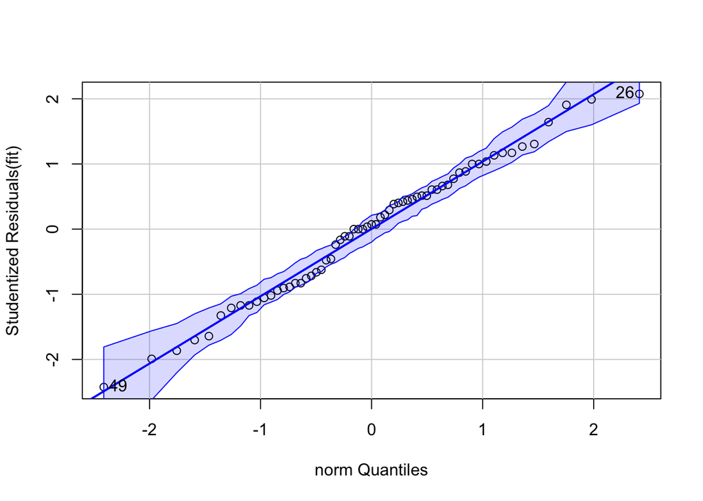

```
## [1] 26 49
```

```r
qqPlot(fit, distribution = "norm")
```

##Looking at the qqplot i would say that the normality assumption is not violated because all the points are between the blue bounds and follow the best fit line very well. Majority of the points are towards the upper half of the best fit line with one outlier close to the bottom and one outlier at the highest point of the graph, but these outliers are still inside the bounds.